### Project 1: Urban Ministries Durham

###### Monica E. Borges, BIOS 611

##### Data source

[Urban Ministries Durham](http://www.umdurham.org/) (UMD) was founded in 1983 and has since served thousands of people in the area in efforts to combat homelessness. The source dataset for this analysis contained 79838 records and 18 variables. For the purposes of this investigation, to focus on data collected since UMD has been operating as a campus, the dataset for analysis includes information from 2001 - 2018, a total of of 75573 records.

##### Goals of this report:

- To describe the growth that UMD has experienced in recent years
- To capture trends about when people are coming and going
- To capture a need associated with increasing visitors: food supply

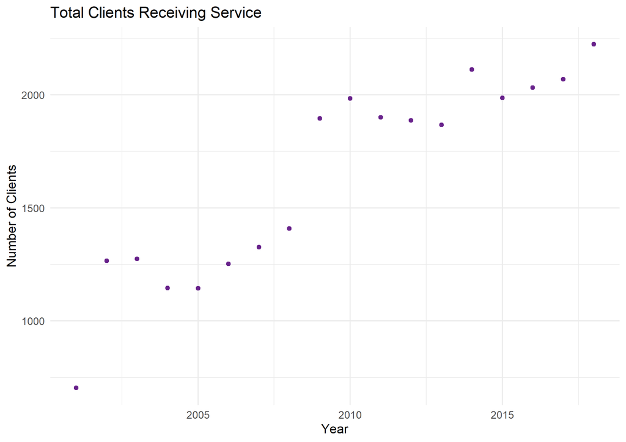

The increase in overall visitors may be attributed to a combination of increased resources at UMD, increased awareness, and increased need in the area.

As displayed below, the number of new clients per month is relatively constant.

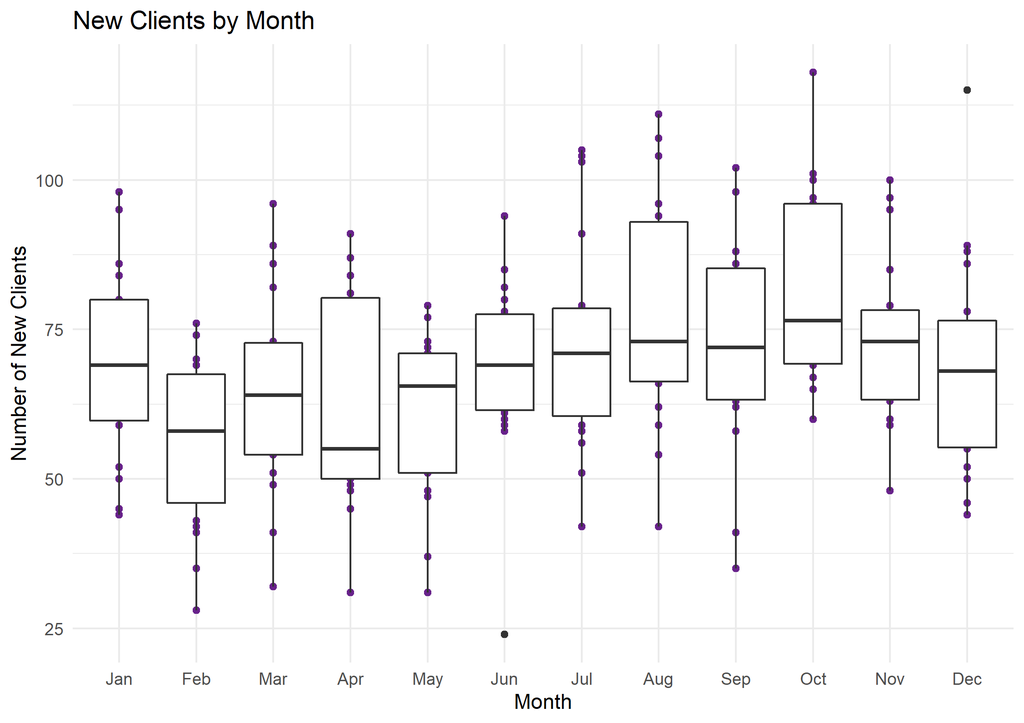

This plot displays the distribution in the number of new visitors per month over the last 20 years. For example, March averages about 60 new clients per month in the past two decades. October sees the highest number of monthly new clients, and April sees the lowest, though the overlapping box plots do not indicate a statistically significant difference.

##### How many services do clients receieve, and how long do they “stay”?

People staying at or passing through UMD can receive several different types of services. The Number of services described in the histogram below is the number of times someone received food, clothing, bus passes, hygiene kit, school supplies, or diapers.

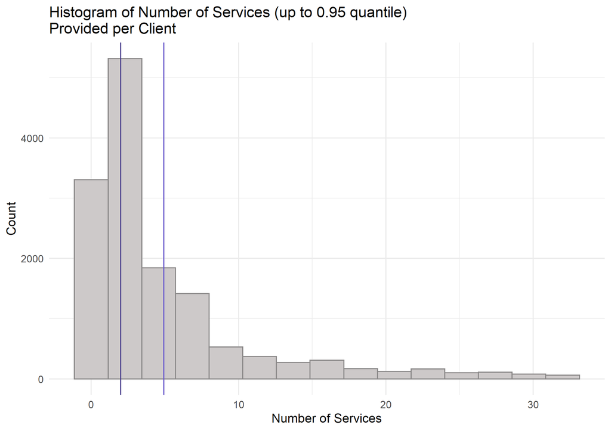

The median number of services is 2, and the mean is 8.1. As many clients (n=6656) have only 1 recorded date where they visited, fewer stay longer or return to UMD, so the distribution of number of services per client is skewed right. This distribution is displayed up to the 0.95 quantile in order to see the lower end of the distribution in better detail.

The range of days between a client’s first and last visit, similarly to the number of services they seek, is skewed to the right.

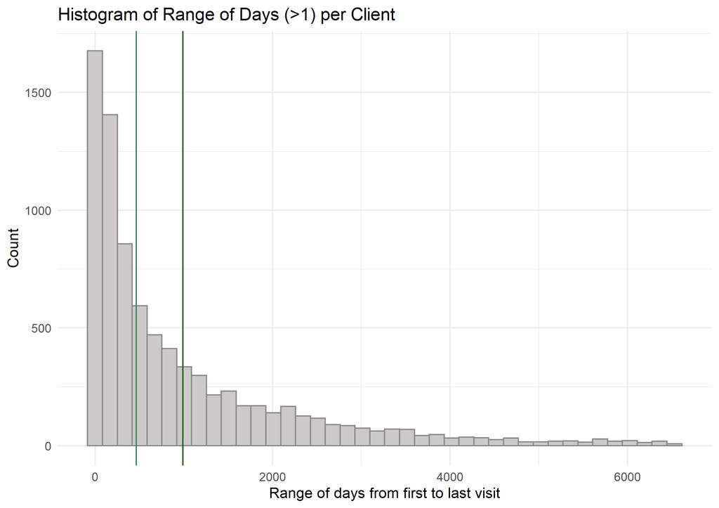

##### During what time of year do people have their last visit at UMD?

Similarly to individuals’ first visit, there is not a standout month when people tend to have their last visit.

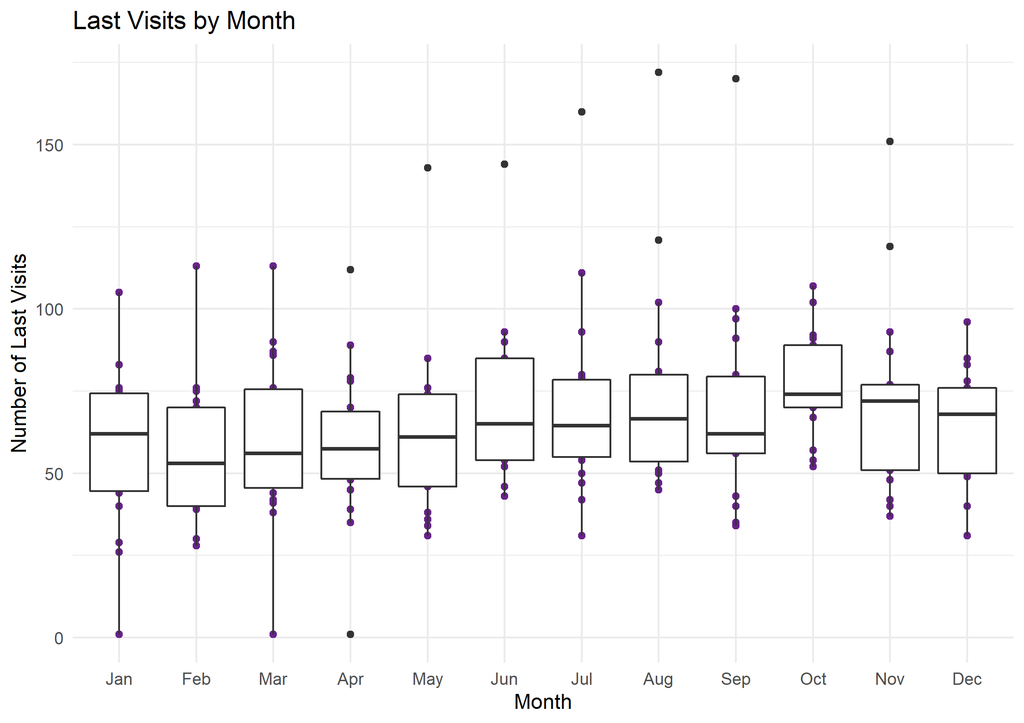

The y-axis above has been truncated to exclude 2 outliers occurring in November-December 2018. I expect that these are current clients or those who recently left UMD, since the data cutoff used here is 2018.

##### What happens around the last visit?

Compared with other instances that clients receive service, the last date is not particularly different. Food and clothing are in overwhelmingly high demand throughout. When we take food and clothing out of the equation, there is a slight difference between services given before and at a person’s last visit.

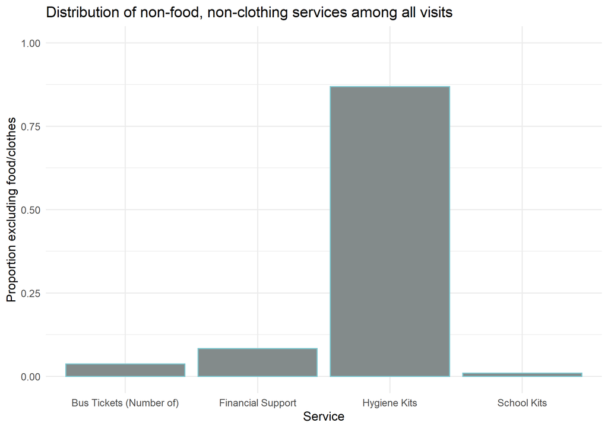

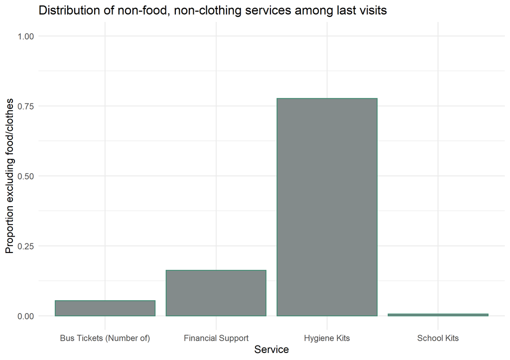

##### Food pounds increase steadily

Food pounds distributed from the pantry and number of clients served are, unsurprisingly, closely associated. The following plot by month excludes months during which food pounds are missing from the source data.

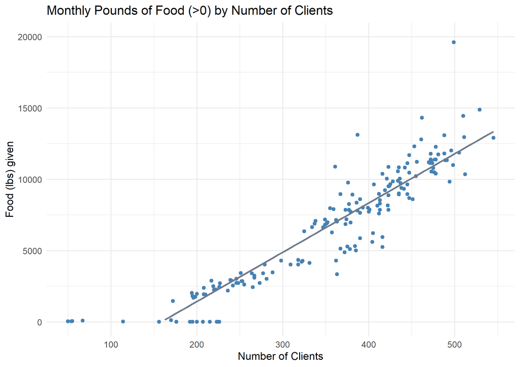

##### Conclusions

Urban ministries has steadily provided services to people in the community since its operation as a campus began in 2001. UMD appears to have momentum in its ability to help clients, and is on track to continue serving Durham individuals. It will not be surprising if food needs continue to increase proportionally with an increase in clients, and new clients can be expected at a relatively constant rate throughout the year.